# Introduction to Bayesian Statistics for Demographic Science

Lab 1: Bayesian inference in Demography

> **Learning Objectives**  
> In this lab, you will learn :  
> - Bayesian inference in practice.  
> - The basics of `CmdStanR`,  
> - Specifying a binomial model in `Stan` and `CmdStanR`.

This Lab is based on workshop designed by Professor Arkadiusz Wiśniowski from the University of Manchester as part of the course on Demographic forecasting of the MSc in Social Research and Statistics.

# 1 Preliminary work

First, create a folder for this Lab and change the working directory to this folder in R

Then, install and load the R packages needed for this session.

```
##
##  C:\Users\andreaa\AppData\Local\Temp\RtmpO2ihus\downloaded_packages
```

```
##
##  C:\Users\andreaa\AppData\Local\Temp\RtmpO2ihus\downloaded_packages
```

# 2 Bayesian inference in practice (basics)

To illustrate how Bayesian inference works in practice, we are going to implement a binomial model which aims at estimating the probability of a baby being born in a given hospital. We want to know what the probability of the baby being a girl is. We can assume (and it is a reasonable assumption) that the outcome variable $Y$ which takes values 0 (boy) or 1 (girl) is generated by Bernoulli trials with some unknown parameter $\theta$ - the probability of the baby being a girl. This is well-described by a **binomial model**: $P(girls=k, n|\theta)$.

- It is nice because if we assume the prior to be Beta distribution, we can derive the posterior by hand.
- Prior: $Beta(a,b)$ has expectation $a/(a+b)$
- **posterior** is also Beta!
- Posterior: $Beta(a+k, b+n-k)$, has expectation $(a+k)/(a+b+n)$
- Note: when posterior looks like prior we call the prior **conjugate**

## 2.1 Defining a prior distribution

What do (can) we know about the probability of the baby being a girl? Let’s try some distributions. We know that the conjugate prior distribution is beta distribution.

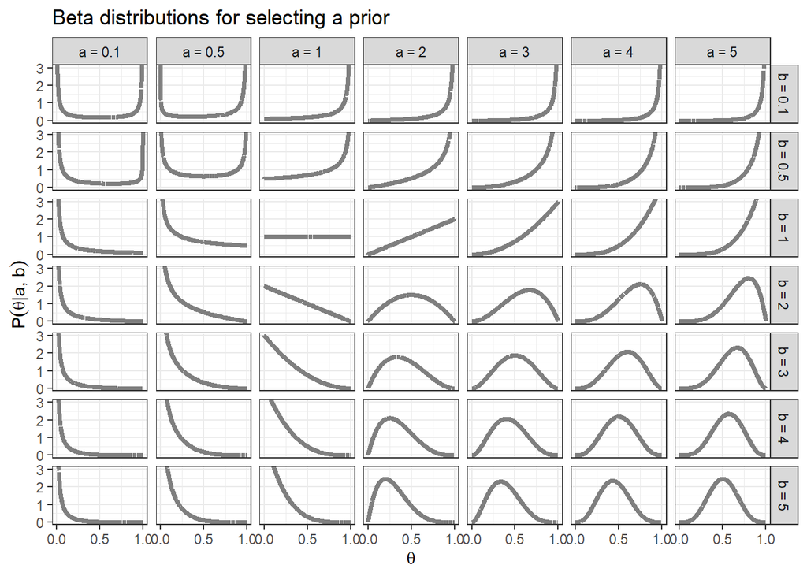

We could define an informative prior based on demographic knowledge with expectation $0.4854369$.

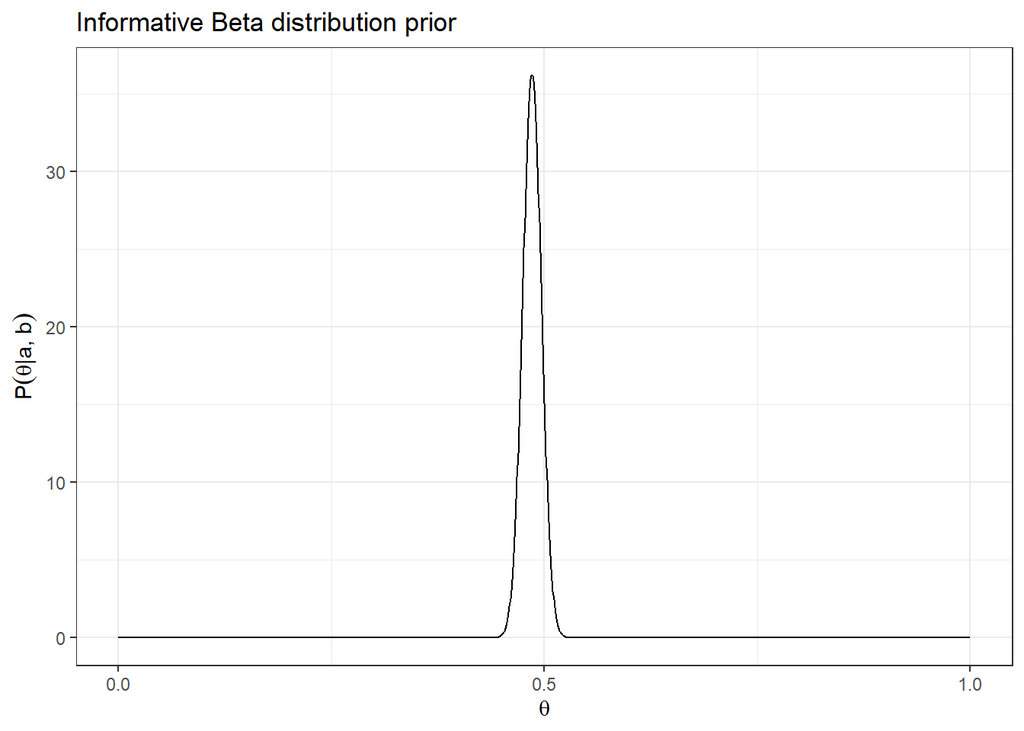

## 2.2 Simulating data

Based on demographic knowledge, we simulate data on the first thousand of babies born in some hospital since the beginning of year 2017 (1 denotes a girl, 0 - a boy).

```r
set.seed(202)
girl <- rbinom(n = 1000, size = 1, prob = 0.4854369)
girl
```

```
##    [1] 0 1 0 0 0 1 0 0 0 1 0 0 0 1 0 0 1 1 1 0 0 1 1 1 0 0 0 0 1 1 0 0 1 1 0 0 1
##   [38] 0 1 1 1 1 1 0 1 0 1 1 1 0 1 0 1 1 1 0 0 1 1 1 1 1 1 0 0 0 0 1 0 0 1 0 0 1
##   [75] 1 1 0 0 0 0 1 1 1 1 0 1 1 0 1 1 1 0 1 1 0 1 1 0 0 0 0 1 1 0 0 1 1 0 1 0 1
##  [112] 1 1 1 1 1 1 1 0 1 1 1 1 0 1 1 0 0 1 0 0 0 1 0 0 0 0 0 1 1 1 0 0 1 0 1 0 1
##  [149] 0 1 0 1 0 0 0 1 0 1 0 1 0 1 1 1 0 0 0 1 0 1 1 0 1 1 1 1 1 1 0 0 0 1 1 0 1
##  [186] 0 0 0 1 0 0 1 1 1 1 1 0 0 1 1 0 0 0 1 0 0 0 1 0 0 0 0 1 1 0 0 1 1 0 0 0 1
##  [223] 0 0 0 1 1 0 1 1 0 1 0 0 1 0 0 0 0 0 1 1 1 0 0 0 0 0 0 1 1 1 0 0 1 1 1 1 1
##  [260] 0 0 1 0 0 0 0 0 1 1 1 1 1 1 0 0 0 0 0 1 0 1 1 0 0 1 1 0 0 1 1 1 0 0 1 0 1
##  [297] 0 0 1 0 0 0 1 0 1 1 1 0 0 0 1 1 0 0 1 1 1 1 0 0 1 0 1 0 1 0 1 0 1 1 1 1 0
##  [334] 1 1 0 0 0 0 0 0 1 1 0 0 0 0 1 1 1 0 1 0 0 0 0 1 1 0 0 1 1 0 0 1 0 1 0 0 0
##  [371] 0 0 1 0 0 0 1 1 0 1 1 1 1 1 0 1 0 1 1 0 1 1 1 1 1 0 1 0 0 1 1 1 1 0 1 1 1
##  [408] 0 1 1 1 1 0 0 0 1 0 0 1 1 1 1 1 0 1 0 0 1 1 1 1 0 0 0 0 1 1 1 1 0 0 1 0 0
##  [445] 0 1 1 1 1 0 0 0 0 1 1 0 0 0 0 1 0 1 0 1 1 0 1 1 1 0 1 1 1 0 0 1 0 1 0 1 0
##  [482] 1 0 1 1 0 1 1 1 1 1 1 0 1 0 0 0 1 0 0 0 1 1 0 1 1 1 0 1 0 1 0 1 0 1 0 0 0
##  [519] 1 0 1 1 0 1 0 0 0 0 0 1 0 0 1 1 1 1 0 1 1 0 0 1 0 1 1 0 0 1 1 0 1 1 0 0 1
##  [556] 0 1 1 1 0 0 0 0 1 0 0 0 1 0 0 1 0 0 1 1 0 0 0 0 1 0 1 1 1 1 1 0 1 1 1 0 1
##  [593] 1 0 1 1 0 1 1 1 0 1 1 1 0 0 0 0 1 0 0 1 0 1 0 0 0 1 1 0 0 1 1 0 0 0 1 0 1
##  [630] 1 1 1 0 0 0 0 0 1 0 0 0 0 0 1 0 1 0 1 0 0 0 0 0 0 0 1 0 1 0 1 0 0 1 1 1 1
##  [667] 1 1 0 0 0 1 0 0 0 0 1 0 0 0 0 0 1 0 0 0 0 1 1 0 0 1 1 1 1 0 1 1 1 1 0 1 0
##  [704] 0 1 0 1 0 0 1 0 0 0 1 1 0 1 1 0 1 1 0 0 0 1 0 0 1 1 1 1 1 1 0 1 0 0 0 1 1
##  [741] 1 0 1 0 0 0 1 1 0 0 1 1 1 1 1 0 0 1 1 0 0 1 1 1 0 1 1 1 0 1 0 0 1 0 0 1 0
##  [778] 1 0 1 0 1 0 1 0 0 0 1 1 1 0 1 0 1 0 0 0 1 0 0 0 1 0 0 1 0 1 1 1 1 0 1 0 0
##  [815] 0 0 0 0 1 1 0 1 1 1 0 0 1 1 1 1 1 1 0 1 1 0 0 1 1 0 1 0 0 0 0 1 1 0 1 0 0
##  [852] 0 1 1 1 0 1 1 0 0 1 0 0 1 1 0 1 1 1 0 0 1 0 1 0 0 1 0 1 0 0 1 1 0 0 0 1 0
##  [889] 1 0 1 0 1 0 0 1 0 0 0 0 0 0 1 0 1 0 1 0 0 1 0 1 1 0 0 0 1 0 0 0 0 1 0 0 0
##  [926] 1 1 1 0 1 1 1 0 1 1 1 0 0 1 0 0 1 1 1 0 1 1 0 0 0 0 0 0 0 0 0 0 1 1 0 1 1
##  [963] 0 0 1 1 1 1 0 1 1 1 0 1 0 0 0 1 0 0 0 0 0 0 1 1 1 0 0 0 0 0 1 0 0 0 1 1 0
## [1000] 0
```

## 2.3 Plotting prior, likelihood and posterior distributions

- What is the posterior distribution of parameter $\theta$ if we use conjugate priors?
- Plot prior distributions along the corresponding likelihood and posteriors.

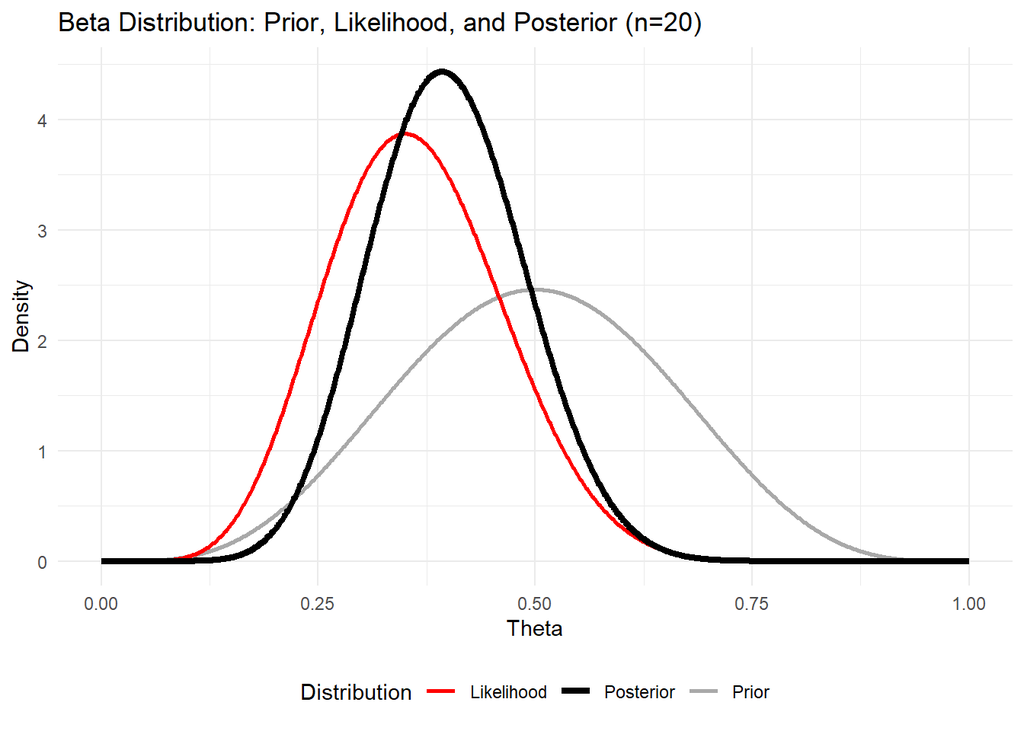

```r
a <- 5
b <- 5
th <- seq(0, 1, by = 0.001)
k <- sum(girl[1:20]) # sample size:  20 observations
n <- length(girl[1:20])

distr <- data.frame(th)
distr$prior <- dbeta(th, a, b)
distr$likelihood <- dbeta(th, k + 1, n - k + 1)
distr$posterior <- dbeta(th, a + k, b + n - k)


d1 <- ggplot(data = distr, aes(x = th)) +
  geom_line(aes(y = prior, color = "Prior"), size = 1) +
  geom_line(aes(y = likelihood, color = "Likelihood"), size = 1) +
  geom_line(aes(y = posterior, color = "Posterior"), size = 1.5) +
  labs(title = "Beta Distribution: Prior, Likelihood, and Posterior (n=20)",
       x = "Theta",
       y = "Density") +
  theme_minimal() +
  scale_color_manual(values = c("Prior" = "darkgrey", "Likelihood" = "red", "Posterior" = "black"), name = "Distribution") +
  theme(legend.position = "bottom")
d1
```

[figure not shown]

```r
th <- seq(0, 1, by = 0.001)
a <- 1000
b <- 1000 * (1 - 0.4854369) / 0.4854369 #informative prior with expectation 0.4854369

a=5
b=5
k <- sum(girl[1:20]) # sample size:  20 observations
n <- length(girl[1:20])

distr <- data.frame(th)
distr$prior <- dbeta(th, a, b)
distr$likelihood <- dbeta(th, k + 1, n - k + 1)
distr$posterior <- dbeta(th, a + k, b + n - k)


d1i <- ggplot(data = distr, aes(x = th)) +
  geom_line(aes(y = prior, color = "Prior"), size = 1) +
  geom_line(aes(y = likelihood, color = "Likelihood"), size = 1) +
  geom_line(aes(y = posterior, color = "Posterior"), size = 1.5) +
  labs(title = "Beta Distribution: (informative) prior, Likelihood, and Posterior (n=20)",
       x = "Theta",
       y = "Density") +
  theme_minimal() +
  scale_color_manual(values = c("Prior" = "darkgrey", "Likelihood" = "red", "Posterior" = "black"), name = "Distribution") +
  theme(legend.position = "bottom")
d1i
```

Arrange the plots in a single layout.

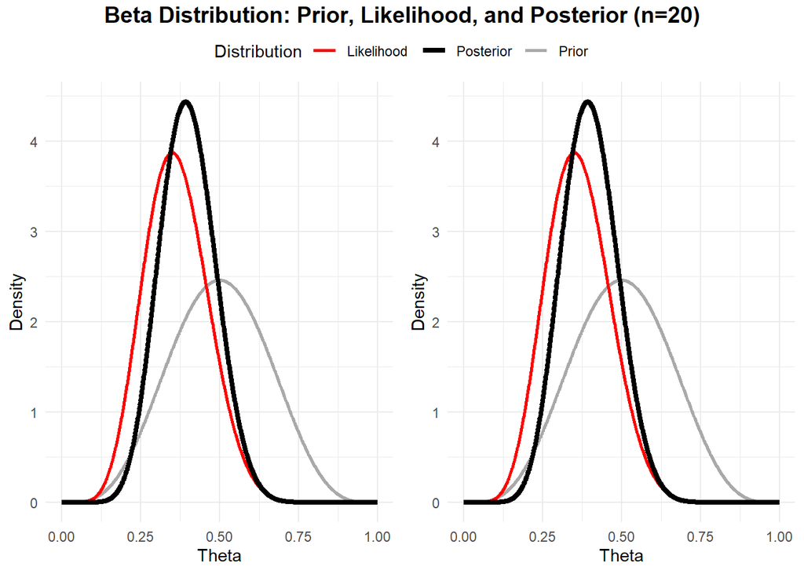

```r
comb_plot <- ggarrange(d1 + theme(plot.title = element_blank()),
          d1i + theme(plot.title = element_blank()), ncol = 2, nrow = 1, common.legend = T)

annotate_figure(
  comb_plot,
  top = text_grob("Beta Distribution: Prior, Likelihood, and Posterior (n=20)", size = 14, face = "bold"),
  right = NULL)
```